# Homework 2 (Week 3)

Jake Fenley

9/21/2021

### [Link to Github](https://github.com/jpFenley/stat433-hw2)

### Part 1: Missing dep_times

**How many flights have a missing dep_time? What other variables are missing? What might these rows represent?**

We filter those flights that have a NA as dep_time. We can then count how many rows this is true for, as well as the proportion of rows this is the case for.

```r
filter(flights, is.na(dep_time))
```

```
## # A tibble: 8,255 x 19
##     year month   day dep_time sched_dep_time dep_delay arr_time sched_arr_time
##    <int> <int> <int>    <int>          <int>     <dbl>    <int>          <int>
##  1  2013     1     1       NA           1630        NA       NA           1815
##  2  2013     1     1       NA           1935        NA       NA           2240
##  3  2013     1     1       NA           1500        NA       NA           1825
##  4  2013     1     1       NA            600        NA       NA            901
##  5  2013     1     2       NA           1540        NA       NA           1747
##  6  2013     1     2       NA           1620        NA       NA           1746
##  7  2013     1     2       NA           1355        NA       NA           1459
##  8  2013     1     2       NA           1420        NA       NA           1644
##  9  2013     1     2       NA           1321        NA       NA           1536
## 10  2013     1     2       NA           1545        NA       NA           1910
## # ... with 8,245 more rows, and 11 more variables: arr_delay <dbl>,
## #   carrier <chr>, flight <int>, tailnum <chr>, origin <chr>, dest <chr>,
## #   air_time <dbl>, distance <dbl>, hour <dbl>, minute <dbl>, time_hour <dttm>
```

```r
filter(flights, is.na(dep_time)) %>% nrow
```

```
## [1] 8255
```

```r
flights$dep_time %>% is.na %>% mean
```

```
## [1] 0.02451184
```

It appears that when dep_time is missing so are dep_delay, arr_time, arr_delay, air_time. It is very likely that the missing values indicate a cancelled flight, as it would not have any time related info if that were the case.

### Part 2: Converting time to minutes

**Currently dep_time and sched_dep_time are convenient to look at, but hard to compute with because they’re not really continuous numbers. Convert them to a more convenient representation of number of minutes since midnight.**

```r
flights <- flights %>% mutate(
  dep_time_min = (dep_time %/% 100) * 60 + (dep_time %% 100),
  sched_dep_time_min = (sched_dep_time %/% 100) * 60 + (sched_dep_time %% 100))

flights %>% select(dep_time, dep_time_min, sched_dep_time, sched_dep_time_min) %>% head
```

```
## # A tibble: 6 x 4
##   dep_time dep_time_min sched_dep_time sched_dep_time_min
##      <int>        <dbl>          <int>              <dbl>
## 1      517          317            515                315
## 2      533          333            529                329
## 3      542          342            540                340
## 4      544          344            545                345
## 5      554          354            600                360
## 6      554          354            558                358
```

### Part 3: Look at the number of canceled flights per day. Is there a pattern? Is the proportion of canceled flights related to the average delay? Use multiple dyplr operations, all on one line, concluding with ggplot(aes(x= ,y=)) + geom_point()

The following plots the cancellation rate and average delay time. Each point corresponds to a day of the year. There does appear to be a positive relationship between the cancellation rate and the average delay time.

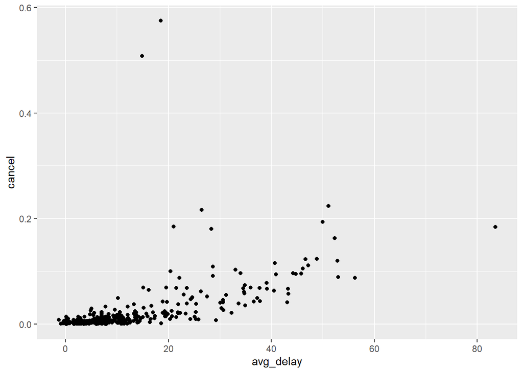

```r
flights %>%
  group_by(yday(time_hour)) %>%
  summarize(cancel = mean(is.na(dep_time)),
            avg_delay = mean(dep_delay, na.rm = TRUE)) %>%
  ggplot(aes(x= avg_delay ,y=cancel)) + geom_point()
```